# Studio › Prints — Print settings · one Download per piece · View as ▾ · All guests ◆ · Everything ◆

Prototype for approval · 2026-10-17 · Fable · nothing built. Left: today's page (live 800b570, the built pictures). Right: the same page with the delta drawn over it — press ⚙, View as ▾, the ◆ buttons, the bar.

Free: every ◆ opens the shipped Pro note. Pro: the same ◆ buttons save the file. Guest names here are invented.

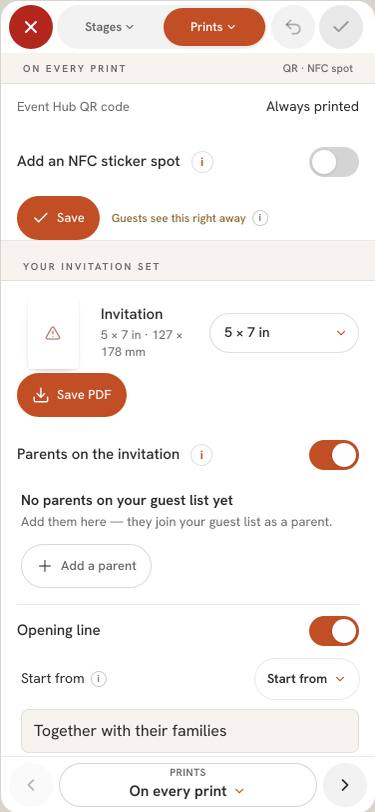

· · · four screens · · ·

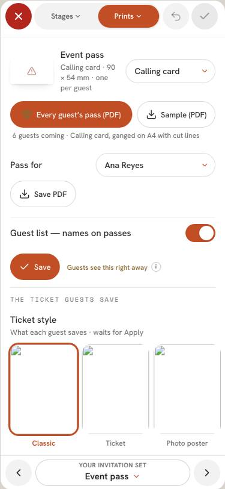

· · · three screens · · ·

[figure not shown]

Decisions sit inside piece rows (Parents, Opening line, E-Gifts, Kindly reply, names on passes, Ticket style, seat plan, chart Layout); the Event pass carries "Every guest's pass", "Sample", "Pass for ▾" and a Save PDF.

**After — the delta**⚙ settings · Download · View as ▾ · ◆

Stages Prints

Which print

Print settings

Download

⚙ opens Print settings. Every piece row: picture · name · size line · size ▾ · Download. Guest pieces add View as ▾ and All guests ◆. The bar: ‹ piece ▾ › and ⬇ (this piece · Everything ◆).

### What moved into Print settings — same fields, same form

Every switch and input that today sits inside a piece row, under small headings, in ONE sheet with the one Save. The shipped print-words form posts the same names (`studio-prints-posts-the-same.test.ts` holds them).

[output not shown]

#### What stays on the piece rows

- **Size ▾** where a piece has sizes — Invitation (5 × 7 in · A5, shared by Entourage, Finer Details and Menu), Event pass (Calling card · ID card (CR80) · Train ticket · Boarding pass · Phone card (3:4 portrait)), Event card (A5 · Index card 5 × 3 in · Index card 6 × 4 in), Entrance chart (A3 · A2 · A1 · 24 × 36 in). One home per decision: the size is picked where the picture redraws, so it is not repeated in settings.
- Two-file prints become ONE dropdown + one Download: 2D seat plan "Colours ▾" (In your colours · Blueprint), Caterer "File ▾" (PDF · Spreadsheet).
- The Menu's dishes and the Love Story's chapters are content, not settings — the Menu row keeps its "Edit menu" door (the shipped editor); the posters' doors to the Love Story stay.
- "Changed since you printed" stays an amber line on its row.

### Guest-based pieces — View as ▾ · Download · All guests ◆

Measured in `lib/print-pieces.ts`, `lib/free-prints.ts` and `/api/hub-print/[piece]/route.ts`. ONE guest picker for all four: pick a guest once and every guest piece redraws for them (coming guests first, then not replied, then maybe; search when long).

| Piece | One guest (free) | All guests ◆ | Today |
| --- | --- | --- | --- |
| Event pass | `pass?pass_guest=<id>` (PDF, the size picked) — exists | `passes` ganged on A4 with cut lines — exists, Pro since 10-16 | "Pass for ▾ · Save PDF", "Every guest's pass (PDF)" ◆, "Sample (PDF)" |
| Digital ticket (PNG) | the guest's own card PNG — exists (the Guest list's per-guest download) | the .zip — exists, Pro since 09-29 | "Digital ticket · Download all" under Ticket style |
| Guest QR codes | one guest's QR (`eventname-guestname.jpg`) — exists on the Guest list, not on Prints | the A4 sheet, 12 to a page — exists; FREE today by the 2026-09-25 ruling ⚠ | "Save PDF" (the sheet) |
| Table signs & place cards | one guest's place card — NEW (`/seating/print?guest=<id>`) | the pack — exists, free today ⚠ | "Save PDF" (the pack) |

**Not per guest**, so no View as: Event card (`layoutCard` takes no guest), Guest list registry, Caterer meal counts, Entrance seating chart, Event QR, the invitation cards and posters.

#### Decided, not asked

- The "Sample (PDF)" button goes: the Event pass's own Download is one real guest's pass (the guest shown), which is what a sample was for.
- The count line keeps the shipped rule: the number IS the file — "109 passes · 6 coming, 103 not replied yet"; place cards count seated guests only.
- Everything ◆ is one PDF of every piece above in the theme being edited — the invitation set, every guest's pass and place card, the day's sheets — and replaces "Download the set"'s two buttons; the piece bar's ⬇ offers "This piece" and "Everything ◆".
- A free couple's ◆ opens the centred Pro note (the shipped `StudioProDoor`), never a page jump; owned, the same button saves the file.

#### For the owner's word ⚠

- **Guest QR codes and the place-card pack** are free today ("the free version is the PDF of QRs if they want to do it themselves", 2026-09-25). Your 10-16 ruling made every "download all" Pro but named only the whole set and every guest's pass. Drawn here as ◆ per today's instruction — say if the QR sheet stays the free way out.
- **The Event card** is the event's card, not a guest's — it has Download only. If you want a per-guest Event card, that is a new layout.
- **Everything** — today's `set` file holds the 8 invitation-set pieces only; the day's sheets and the pass batch would be appended by the route.

#### Where a builder would touch (no code in this prototype)

- `maker-details.tsx` — the Studio editors: move the include switches, Parents, Opening line, Kindly reply, names on passes, Ticket style, poster Background, seat plan and chart layout into one "print-settings" editor (same `WORDS_FORM`, same names); the piece editors keep head · size ▾ · Download.
- `maker-prints.tsx` — `PrintPieceEditor` (Studio): one Download; guest pieces get View as ▾ (`StudioOnePass` generalised: one shared guest state), Download for that guest, All guests ◆ (`allInOneFile`); `PassCardsPanel`'s rows fold in; `PrintSetDownloads` becomes Everything ◆.
- `studio-prints-bar.tsx` + `details-workspace.tsx` — "Print settings" as the bar's first item; the ⬇ step opening the Download sheet.
- `lib/maker-details-items.ts` · `lib/studio-details.ts` — the settings item in place of "On every print"; `lib/studio-prints-six.ts` — Pro notes for the QR sheet, the place cards and Everything.
- `app/api/hub-print/[piece]/route.ts` — Everything (the set + passes + the day's sheets, Pro); `qr-codes?guest=` one guest; `app/dashboard/[eventId]/seating/print/route.ts` — `guest=` one place card; `isAllInOnePrint` grows if the QR sheet and the pack go Pro.
- Guards to re-read first: `studio-prints-posts-the-same.test.ts`, `studio-prints-money-is-unchanged.test.ts`, `all-in-one-prints-are-pro.test.ts`, `studio-prints-navigation.test.ts`, `every-print-shows-its-picture.test.ts`.